# Trend Analysis Code Practice

DACSS631/COMM408

2024-09-22

## What are we doing here?

This is a practice script (in R Markdown format) on the topic *Trend Analysis*. We’ll start with a code demo, accompanied by guiding questions to facilitate the learning process. Following this, we’ll dive into coding challenges 2.

# Step 1: Load the data

You can import either a local file or a cloud-hosted file using a URL.

```r
## load libraries. Make sure the libraries are installed
library(readr)
library(ggplot2)
library(ggthemes)
library(lubridate)
library(reshape2)
library(dplyr)
library(stringr)
library(tidyr)
library(DT)


## Import external data files through the provided URL.
df <- read_csv("https://curiositybits.cc/files/nfl.csv")

datatable(df[1:25,],)  #display the data frame and show the first 25 rows.
```

|  | Account | User Name | Followers at Posting | Post Created | Post Created Date | Post Created Time | Type | Total Interactions | Likes | Comments | Views | Like and View Counts Disabled | URL | Link | Photo | Title | Description | Image Text | Sponsor Id | Sponsor Name | Overperforming Score (weighted — Likes 1x Comments 1x ) |
| --- | --- | --- | --- | --- | --- | --- | --- | --- | --- | --- | --- | --- | --- | --- | --- | --- | --- | --- | --- | --- | --- |
| 1 | NFL | nfl | 28310698 | 2023-09-24 20:27:41 EDT | 2023-09-24 | 20:27:41 | Album | 78150 | 77230 | 920 | 0 | False | https://www.instagram.com/p/CxmDwAZp9Ha/ | https://www.instagram.com/p/CxmDwAZp9Ha/ | https://scontent-sea1-1.cdninstagram.com/v/t51.29350-15/382278027_320811477265544_2170861388751703189_n.jpg?_nc_cat=1&amp;ccb=1-7&amp;_nc_sid=8ae9d6&amp;_nc_ohc=Ld3DeOMDX5QAX_WvV7r&amp;_nc_ht=scontent… |  | More Week 3️⃣ dubs! 😤 |  |  |  | 1.61 |
| 2 | NFL | nfl | 28310698 | 2023-09-24 20:05:41 EDT | 2023-09-24 | 20:05:41 | Album | 457476 | 454692 | 2784 | 0 | False | https://www.instagram.com/p/CxmBO1lP44Q/ | https://www.instagram.com/p/CxmBO1lP44Q/ | https://scontent-sea1-1.cdninstagram.com/v/t51.29350-15/381665144_975646620397944_7797985043285789457_n.jpg?_nc_cat=1&amp;ccb=1-7&amp;_nc_sid=8ae9d6&amp;_nc_ohc=U5fKORdZESUAX_0_zod&amp;_nc_oc=AQnAgEpU… |  | Chiefs Kingdom 🤝 Swifties (via @nflonfox) |  |  |  | 9.45 |
| 3 | NFL | nfl | 28310698 | 2023-09-24 19:38:09 EDT | 2023-09-24 | 19:38:09 | Album | 81018 | 78972 | 2046 | 0 | False | https://www.instagram.com/p/Cxl-FNhPdT5/ | https://www.instagram.com/p/Cxl-FNhPdT5/ | https://scontent-sea1-1.cdninstagram.com/v/t51.29350-15/382326397_241229935584451_4126036529442962549_n.jpg?_nc_cat=1&amp;ccb=1-7&amp;_nc_sid=8ae9d6&amp;_nc_ohc=Zmgh_55DmRMAX_DEHky&amp;_nc_ht=scontent… |  | @azcardinals get their first dub of the season 😤 |  |  |  | 1.22 |
| 4 | NFL | nfl | 28310698 | 2023-09-24 19:31:32 EDT | 2023-09-24 | 19:31:32 | Album | 137544 | 136732 | 812 | 0 | False | https://www.instagram.com/p/Cxl9UpyvCaI/ | https://www.instagram.com/p/Cxl9UpyvCaI/ | https://scontent-sea1-1.cdninstagram.com/v/t51.29350-15/381485600_1043842360135683_6179901029945193522_n.jpg?_nc_cat=1&amp;ccb=1-7&amp;_nc_sid=8ae9d6&amp;_nc_ohc=jGmItfOYbmUAX9Zz_lZ&amp;_nc_ht=sconten… |  | Now you see him, now you don’t. |  |  |  | 2.08 |
| 5 | NFL | nfl | 28310698 | 2023-09-24 19:09:29 EDT | 2023-09-24 | 19:09:29 | Album | 104307 | 103069 | 1238 | 0 | False | https://www.instagram.com/p/Cxl6zPnvmil/ | https://www.instagram.com/p/Cxl6zPnvmil/ | https://scontent-sea1-1.cdninstagram.com/v/t51.29350-15/381619425_852715143010890_7035144372422239270_n.jpg?_nc_cat=1&amp;ccb=1-7&amp;_nc_sid=8ae9d6&amp;_nc_ohc=NQ1wN1QB-ZQAX_AMyVw&amp;_nc_ht=scontent… |  | Imagine chest bumping Taylor Swift lol |  |  |  | 1.58 |
| 6 | NFL | nfl | 28310698 | 2023-09-24 18:35:37 EDT | 2023-09-24 | 18:35:37 | Album | 262216 | 260850 | 1366 | 0 | False | https://www.instagram.com/p/Cxl27LJRc-i/ | https://www.instagram.com/p/Cxl27LJRc-i/ | https://scontent-sea1-1.cdninstagram.com/v/t51.29350-15/382108563_175656545571042_6940807713458531216_n.jpg?_nc_cat=1&amp;ccb=1-7&amp;_nc_sid=8ae9d6&amp;_nc_ohc=ABsEs54sLc4AX8Z5wTn&amp;_nc_ht=scontent… |  | Alright now 😏 📺: #CHIvsKC on FOX 📱: Stream on #NFLPlus |  |  |  | 3.96 |
| 7 | NFL | nfl | 28310698 | 2023-09-24 18:21:28 EDT | 2023-09-24 | 18:21:28 | Photo | 53064 | 52570 | 494 | 0 | False | https://www.instagram.com/p/Cxl1Thsxaya/ | https://www.instagram.com/p/Cxl1Thsxaya/ | https://scontent-sea1-1.cdninstagram.com/v/t51.29350-15/383752928_844972060314430_9101239916136617407_n.jpg?_nc_cat=1&amp;ccb=1-7&amp;_nc_sid=8ae9d6&amp;_nc_ohc=nr6lW-KEBJ0AX8NV8lo&amp;_nc_ht=scontent… |  | Fastest QB ever to reach 25,000 passing yards (83 games) 👑 |  |  |  | -1.79 |
| 8 | NFL | nfl | 28310698 | 2023-09-24 18:02:27 EDT | 2023-09-24 | 18:02:27 | Photo | 203211 | 201542 | 1669 | 0 | False | https://www.instagram.com/p/CxlzINcyzle/ | https://www.instagram.com/p/CxlzINcyzle/ | https://scontent-sea1-1.cdninstagram.com/v/t51.29350-15/382462112_1517756855663354_3196772113324090701_n.jpg?_nc_cat=1&amp;ccb=1-7&amp;_nc_sid=8ae9d6&amp;_nc_ohc=BuH13rKJpQgAX9owRRX&amp;_nc_ht=sconten… |  | Are the Chiefs going to get 70 too?! | NKH 0 34 HALFTIME K |  |  | 2.14 |
| 9 | NFL | nfl | 28310698 | 2023-09-24 17:30:39 EDT | 2023-09-24 | 17:30:39 | Album | 64144 | 63903 | 241 | 0 | False | https://www.instagram.com/p/CxlvfWbAgIa/ | https://www.instagram.com/p/CxlvfWbAgIa/ | https://scontent-sea1-1.cdninstagram.com/v/t51.29350-15/381396322_1137818883843520_3527843793041352581_n.jpg?_nc_cat=1&amp;ccb=1-7&amp;_nc_sid=8ae9d6&amp;_nc_ohc=9DMnJ4wkx3EAX9aqur9&amp;_nc_ht=sconten… |  | @djchark82 put that man in a spin cycle 😵‍💫 |  |  |  | -1.13 |
| 10 | NFL | nfl | 28310698 | 2023-09-24 17:18:56 EDT | 2023-09-24 | 17:18:56 | Album | 131841 | 131545 | 296 | 0 | False | https://www.instagram.com/p/CxluJg1vfFg/ | https://www.instagram.com/p/CxluJg1vfFg/ | https://scontent-sea1-1.cdninstagram.com/v/t51.29350-15/382852566_835550908297475_6688165589781338703_n.jpg?_nc_cat=1&amp;ccb=1-7&amp;_nc_sid=8ae9d6&amp;_nc_ohc=0PGCicPe2OkAX-yYSyp&amp;_nc_ht=scontent… |  | MLB Hall of Famer AND NFL photographer 👏 📷: via @azcardinals |  |  |  | 1.83 |

[output cut: 15 more lines]

**Q: How many rows and columns does the object df contain?**

**Q: What columns show the effectiveness of online engagement?**

**Q: Which column shows the timestamps?**

**Can find the most liked post?**

# Step 2: Standardize timestamps

```r
df$created_date <- ymd_hms(df$`Post Created`)
df$created_date <- with_tz(df$created_date,"America/New_York")
df$created_date <- as.Date(df$created_date)
```

**Q: What is the timestamp format in the original timestamp column?**

**Q: What is with_tz() and as.Date()?**

**Q: What is the column ‘created_date’?**

**Find the earliest and latest dates in df.**

# Step 3: Explore columns

```r
summary(df$`Followers at Posting`)
```

```
##     Min.  1st Qu.   Median     Mean  3rd Qu.     Max.     NA's
## 12222508 15774680 19383134 19656725 22814001 28319518       17
```

```r
summary(df$`Total Interactions`)
```

```
##    Min. 1st Qu.  Median    Mean 3rd Qu.    Max.
##      52   85034  147791  184177  242798 2408421
```

```r
summary(df$Comments)
```

```
##    Min. 1st Qu.  Median    Mean 3rd Qu.    Max.
##       5     458     865    1519    1701   58659
```

```r
summary(df$Likes)
```

```
##    Min. 1st Qu.  Median    Mean 3rd Qu.    Max.
##       0   84408  146733  182658  240721 2403518
```

```r
summary(df$Views)
```

```
##     Min.  1st Qu.   Median     Mean  3rd Qu.     Max.
##        0        0   289330   614960   922152 13746360
```

**Q: What is the highest Likes count?**

**Q: What is the average Comments count?**

# Step 4: Summarize data by date and Type

```r
df$date_label <- as.factor(df$created_date)   # dates as categorical data.
df$Type <- as.factor(df$Type) # The 'Type' column as categorical data

## Summarize data by date and Type
daily_count <- df %>%
  group_by(date_label, Type) %>%  #group the dataset by the two columns: date_label and Type
  summarise(avg_totalinteractions = mean(`Total Interactions`),
            avg_likes = mean(Likes), #get the average of like counts
            avg_comments = mean(Comments),# get the average of comment count
            avg_followercount = mean(`Followers at Posting`),
            post_count = length(unique(URL))) #get the total unique post count per day and per type

daily_count <- daily_count %>% pivot_longer(cols = -c(date_label, Type), names_to = "variable", values_to = "value") #convert daily_count to a long form.

datatable(daily_count[1:25,], )  #display the data frame and show the first 25 rows.
```

|  | date_label | Type | variable | value |
| --- | --- | --- | --- | --- |
| 1 | 2018-09-24 | Photo | avg_totalinteractions | 207389 |
| 2 | 2018-09-24 | Photo | avg_likes | 205119.6666666667 |
| 3 | 2018-09-24 | Photo | avg_comments | 2269.333333333333 |
| 4 | 2018-09-24 | Photo | avg_followercount | 12222508 |
| 5 | 2018-09-24 | Photo | post_count | 3 |
| 6 | 2018-09-24 | Video | avg_totalinteractions | 91014 |
| 7 | 2018-09-24 | Video | avg_likes | 89982 |
| 8 | 2018-09-24 | Video | avg_comments | 1032 |
| 9 | 2018-09-24 | Video | avg_followercount | 12222508 |
| 10 | 2018-09-24 | Video | post_count | 1 |

[output cut: 15 more lines]

**Look at the newly created dataframe object called daily_count and explain how the numbers are generated.**

# Step 5: Use ggplot2 to plot daily counts by Type

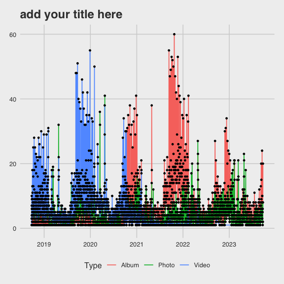

```r
daily_count$date_label <- as.Date(daily_count$date_label) ## in order for the dates to be plotted, the date_label column must be converted back to Date

ggplot(data = daily_count[daily_count$variable=="post_count",], aes(x = date_label, y = value, group = Type)) + ##this shows data points whose value on the variable column matches "post_count"
  geom_line(linewidth = 0.6, alpha = 1.7, aes(color = Type)) +
  geom_point(size = 1) +
  ylim(0, NA) +
  theme(legend.title=element_blank(), axis.title.x = element_blank()) +
  ylab("add your Y axis here") +
  ggtitle("add your title here") +
  theme_fivethirtyeight(base_size = 12, base_family = "sans")
```

**Q: How to change the plot to show the daily average counts of likes?**

# Step 6: Use highcharter for interactive plotting

```r
library(highcharter)

title <- paste0("Daily total interactions ", Sys.Date())
highchart() %>%
  hc_add_series(daily_count[daily_count$variable=="avg_totalinteractions",],"line", hcaes(x = date_label, y = value,group=Type)) %>%
  hc_xAxis(type = "datetime")
```

[interactive chart not shown]

**Q: How to change the plot to show the daily average counts of comments?**

# Step 7: Use Prophet for forecasting

**An optional task for COMM students, but required for DACSS students.**

More on prophet, the automated forecasting algorithm made by Meta: https://facebook.github.io/prophet/

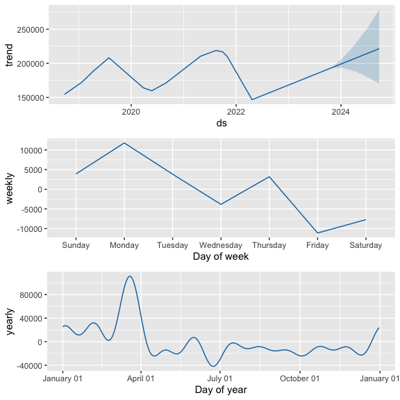

```r
library(prophet)

forcase <- df[,c("date_label","Likes")] #create a subset dataframe to include only the date column and the column that indicates an engagement outcome
colnames(forcase) <-c("ds","y") #change the column names to fit the requirement of the prophet library

m <- prophet(forcase, weekly.seasonality=TRUE) #make forecast!
future <- make_future_dataframe(m, periods = 365)
forecast <- predict(m, future) #make prediction!

prophet_plot_components(m, forecast) #plot the outcome
```